# Cohort-Based Analysis of Proficiency Trends

Longitudinal Performance Report

# 1 Background and Purpose

State summative assessment results in **MATHEMATICS** for **Grade 5** show a **decrease** of **2.6** percentage points in overall proficiency rates and a **decrease** of **0.1** percentage points in advanced proficiency rates in **2023-2024** compared to **2022-2023** (Proficiency changed from **70.3%** to **67.7%**; Advanced proficiency changed from **30.3%** to **30.2%**). This report uses a cohort-based, longitudinal lens to investigate these changes by tracking student performance over time, assessing cohort persistence, and examining demographic and mobility patterns.

Cohort-based analysis follows groups of students as they progress through grades over multiple years, allowing us to distinguish between cohort effects and broader systemic trends. This analysis includes students enrolled in **Grades 3 through 7** during the academic years **2019-2020** through **2023-2024**. The focus of this report is on **Grade 5** proficiency outcomes in **2023-2024**. For example, one cohort tracked in this report began in **Grade 4** during **2022-2023** and progressed to **Grade 5** in **2023-2024**.

The goal of this report is to determine whether the observed change in **MATHEMATICS** proficiency in **Grade 5** is part of a larger cohort trend, a shift in student composition, or a deviation from prior performance trajectories. By comparing multiple cohorts who have passed through **Grade 5** in recent years, we aim to provide insight into whether the observed change is expected, an anomaly, or a sign of a broader pattern that merits further attention.

## 1.1 Assessment Participation by Grade and Year

| GRADE | 2019-2020 | 2020-2021 | 2021-2022 | 2022-2023 | 2023-2024 |
| --- | --- | --- | --- | --- | --- |
| 3 | 4323 | 4502 | 4477 | 4695 | 4863 |
| 4 | 4405 | 4444 | 4574 | 4575 | 4792 |
| 5 | 4282 | 4498 | 4532 | 4646 | 4618 |
| 6 | 4462 | 4370 | 4518 | 4598 | 4756 |
| 7 | 4579 | 4673 | 4541 | 4538 | 4634 |
| Total | 22051 | 22487 | 22642 | 23052 | 23663 |

In **2023-2024**, a total of **4,618** students took the **MATHEMATICS** assessment in **Grade 5**. This reflects a **decrease** of **28** students compared to 2022-2023. Understanding changes in tested student counts helps contextualize year-over-year shifts in proficiency.

## 1.2 Proficiency Trends Across Grades and Years

Proficiency Rates by Grade and Academic Year

|  | 2019-2020 | 2020-2021 | 2021-2022 | 2022-2023 | 2023-2024 |
| --- | --- | --- | --- | --- | --- |
| 3 | 76.5 | 78.5 | 77.5 | 79.1 | 75.9 |
| 4 | 74.1 | 77.4 | 79.0 | 76.0 | 77.9 |
| 5 | 73.1 | 73.8 | 73.8 | 70.3 | 67.7 |
| 6 | 62.5 | 63.7 | 64.9 | 64.6 | 64.8 |
| 7 | 52.1 | 49.9 | 57.9 | 49.5 | 58.7 |

The table above shows **percent proficient** for each **grade level** across academic years **2019-2020** through **2023-2024**. These figures reflect students who tested at each grade level in each year, allowing us to observe how proficiency rates have changed over time across grades.

Advanced Proficiency Rates by Grade and Academic Year

|  | 2019-2020 | 2020-2021 | 2021-2022 | 2022-2023 | 2023-2024 |
| --- | --- | --- | --- | --- | --- |
| 3 | 31.5 | 35.3 | 31.5 | 35.7 | 30.4 |
| 4 | 24.4 | 31.0 | 31.2 | 29.5 | 31.0 |
| 5 | 33.9 | 32.0 | 36.0 | 30.3 | 30.2 |
| 6 | 26.2 | 24.9 | 27.7 | 27.3 | 27.5 |
| 7 | 20.7 | 20.1 | 25.9 | 20.5 | 27.5 |

This table shows the percentage of students scoring at the **top 1** achievement level(advanced proficiency) for each **grade level** across academic years **2019-2020** through **2023-2024**. These results help highlight trends in higher-level performance across grades and time.

# 2 Cohort Overview

A total of 25 student cohorts were identified across entry years 2019-2020, 2020-2021, 2021-2022, 2022-2023, 2023-2024. Initial cohort sizes ranged from 373 to 4853 students (average: 1927). On average, 85.6% of students from each cohort remained on track and were still present in the final observed year. This information provides context for understanding persistence patterns across cohorts and may help distinguish systemic trends from anomalies in proficiency outcomes.

Summary of student cohorts by grade and year.

| Cohort | 2019-2020 | 2020-2021 | 2021-2022 | 2022-2023 | 2023-2024 |
| --- | --- | --- | --- | --- | --- |
| Grade 3 in 2019 | 4323 | 3881 | 3634 | 3391 | 3215 |
| Grade 4 in 2019 |  | 4405 | 3964 | 3581 | 3374 |
| Grade 5 in 2019 |  |  | 4282 | 3794 | 3547 |
| Grade 6 in 2019 |  |  |  | 4462 | 4064 |
| Grade 7 in 2019 |  |  |  |  | 4579 |
| Grade 3 in 2020 | 4487 | 4042 | 3808 | 3553 |  |
| Grade 4 in 2020 |  | 552 | 449 | 390 | 350 |
| Grade 5 in 2020 |  |  | 529 | 422 | 359 |
| Grade 6 in 2020 |  |  |  | 553 | 440 |
| Grade 7 in 2020 |  |  |  |  | 588 |
| Grade 3 in 2021 | 4455 | 4056 | 3792 |  |  |
| Grade 4 in 2021 |  | 508 | 408 | 345 |  |
| Grade 5 in 2021 |  |  | 425 | 324 | 276 |
| Grade 6 in 2021 |  |  |  | 478 | 382 |
| Grade 7 in 2021 |  |  |  |  | 487 |
| Grade 3 in 2022 | 4682 | 4237 |  |  |  |
| Grade 4 in 2022 |  | 491 | 394 |  |  |
| Grade 5 in 2022 |  |  | 398 | 309 |  |
| Grade 6 in 2022 |  |  |  | 454 | 358 |
| Grade 7 in 2022 |  |  |  |  | 373 |
| Grade 3 in 2023 | 4853 |  |  |  |  |
| Grade 4 in 2023 |  | 536 |  |  |  |
| Grade 5 in 2023 |  |  | 391 |  |  |
| Grade 6 in 2023 |  |  |  | 510 |  |
| Grade 7 in 2023 |  |  |  |  | 382 |

# 3 Grade Transition Patterns

Understanding how students progress through grades—whether they repeat, skip, or re-enter after time away—offers important context for interpreting cohort-based trends. While most students follow a traditional linear path, a small but meaningful share experience deviations in grade progression. These transitions can influence both cohort persistence and achievement results in later sections of the report.

This section summarizes the types of grade transitions observed among students in the current dataset.

## 3.1 Summary by Academic Year

The table below shows how many students experienced each type of transition in each academic year.

Number of Students by Transition Type and Year

| Academic Year | Grade Transition | Frequency | Total | Percent |
| --- | --- | --- | --- | --- |
| 2020-2021 | Drop Back | 0 | 15778 | 0.0 |
| 2020-2021 | Repeat | 68 | 15778 | 0.4 |
| 2020-2021 | Skip | 7 | 15778 | 0.0 |
| 2020-2021 | Stay | 15703 | 15778 | 99.5 |
| 2021-2022 | Drop Back | 0 | 16289 | 0.0 |
| 2021-2022 | Repeat | 121 | 16289 | 0.7 |
| 2021-2022 | Skip | 8 | 16289 | 0.0 |
| 2021-2022 | Stay | 16160 | 16289 | 99.2 |
| 2022-2023 | Drop Back | 0 | 16654 | 0.0 |
| 2022-2023 | Repeat | 62 | 16654 | 0.4 |
| 2022-2023 | Skip | 12 | 16654 | 0.1 |
| 2022-2023 | Stay | 16580 | 16654 | 99.6 |
| 2023-2024 | Drop Back | 0 | 16991 | 0.0 |
| 2023-2024 | Repeat | 59 | 16991 | 0.3 |
| 2023-2024 | Skip | 9 | 16991 | 0.1 |
| 2023-2024 | Stay | 16923 | 16991 | 99.6 |

**Interpretation Tip**

Repeaters may contribute to observed declines in cohort persistence rates, while skippers may increase apparent achievement levels for some grade-years.  
Understanding these patterns can help contextualize shifts in proficiency and mobility trends explored later in this report.

## 3.2 Overall Transition Frequencies

This table summarizes the overall frequency of each grade transition type.

Overall Frequency of Grade Transition Types

| Academic Year | Enrollment Transition | Frequency | Total | Percent |
| --- | --- | --- | --- | --- |
| 2019-2020 | Enrolled | 22051 | 22051 | 100.0 |
| 2019-2020 | Return | 0 | 22051 | 0.0 |
| 2020-2021 | Enrolled | 6709 | 6709 | 100.0 |
| 2020-2021 | Return | 0 | 6709 | 0.0 |
| 2021-2022 | Enrolled | 6353 | 6504 | 97.7 |
| 2021-2022 | Return | 151 | 6504 | 2.3 |
| 2022-2023 | Enrolled | 6398 | 6603 | 96.9 |
| 2022-2023 | Return | 205 | 6603 | 3.1 |
| 2023-2024 | Enrolled | 6672 | 6864 | 97.2 |
| 2023-2024 | Return | 192 | 6864 | 2.8 |

## 3.3 Grade Entry and Achievement Patterns

This section explores how students entered Grade **5** by examining how the composition of the grade changed across academic years. Students are grouped based on their enrollment patterns. Some repeated the grade, meaning they were in the same grade both last year and this year. Others stayed on track by advancing one grade level as expected. A few skipped into the grade from two or more levels below, while others skipped over the grade entirely, moving from a lower grade last year to a higher grade this year. Finally, some students joined the grade without being observed in the previous year — often due to transferring in or newly entering the data system. These patterns provide insight into how student movement may influence achievement outcomes.

Summary of Grade 5 Entry Types Across Academic Years

| Academic Year | Total | Repeat | Stay | Skip In | Skip Over | Join |
| --- | --- | --- | --- | --- | --- | --- |
| 2020-2021 | 4498 | 3 | 3964 | 2 | 1 | 529 |
| 2021-2022 | 4532 | 12 | 4048 | 2 | 2 | 470 |
| 2022-2023 | 4646 | 7 | 4185 | 1 | 4 | 453 |
| 2023-2024 | 4618 | 11 | 4175 | 2 | 1 | 430 |

From **2022-2023** to **2023-2024**, the composition of students entering Grade **5** changed as follows: **Repeat** **increased** by **4** students (*0.1% of cohort*); **Stay** **decreased** by **10** students (*0.2% of cohort*); **Skip In** **increased** by **1** students (*0% of cohort*); **Skip Over** **decreased** by **3** students (*0.1% of cohort*); **Join** **decreased** by **23** students (*0.5% of cohort*).

# 4 Mobility Analysis

## 4.1 Summary of Key Findings

This analysis examines student achievement across mobility groups, focusing on a cohort that progressed from Grade 4 in 2022-2023 to Grade 5 in 2023-2024 . The ‘Stay’ group represents the same students observed in both years. Students who stayed performed better than those who joined the school system, while students who left performed similarly to those who remained.

## 4.2 Proficiency Rates by Mobility Group

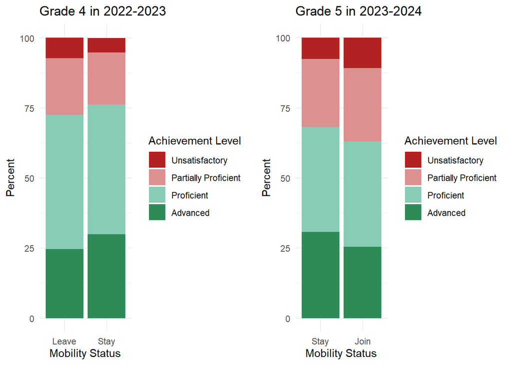

In 2023-2024 , 68.2% of students who stayed scored at or above proficient, compared to 63.0% among those who joined and 72.6% among those who left. Students who joined performed notably below the ‘Stay’ group, while those who left performed similarly.

## 4.3 Distribution of Achievement Levels

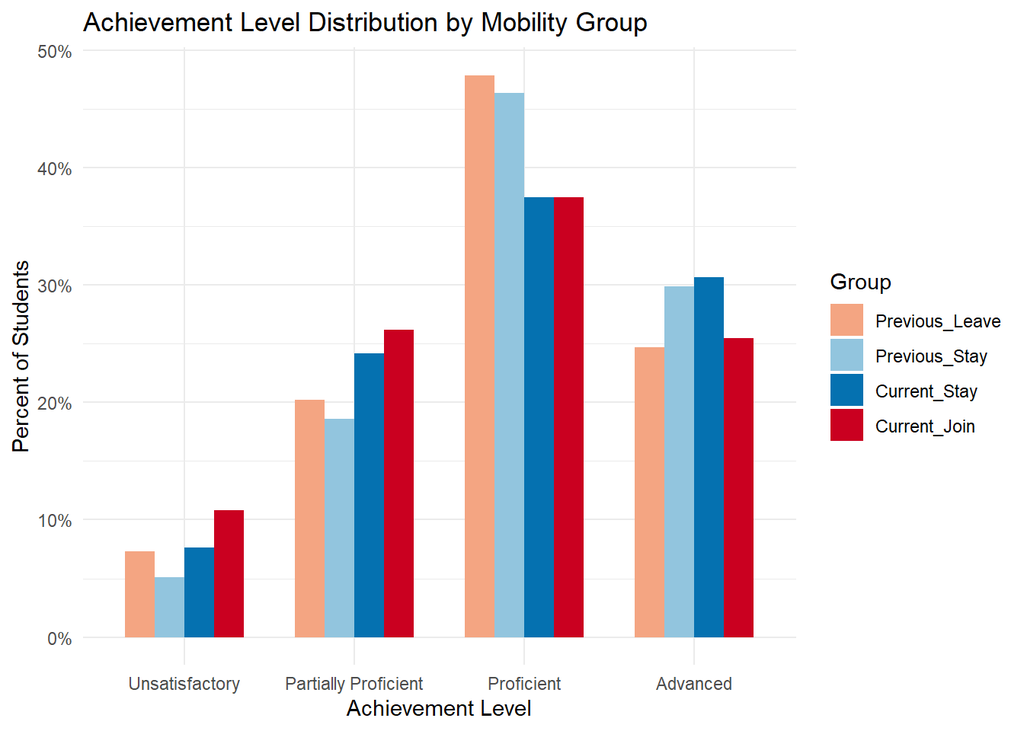

This grouped bar chart shows how achievement levels are distributed across four categories: students who stayed or left in the previous year, and those who stayed or joined in the current year. This format helps identify shifts in proficiency related to student mobility transitions.

## 4.4 Achievement Level Changes for “Stay” Students

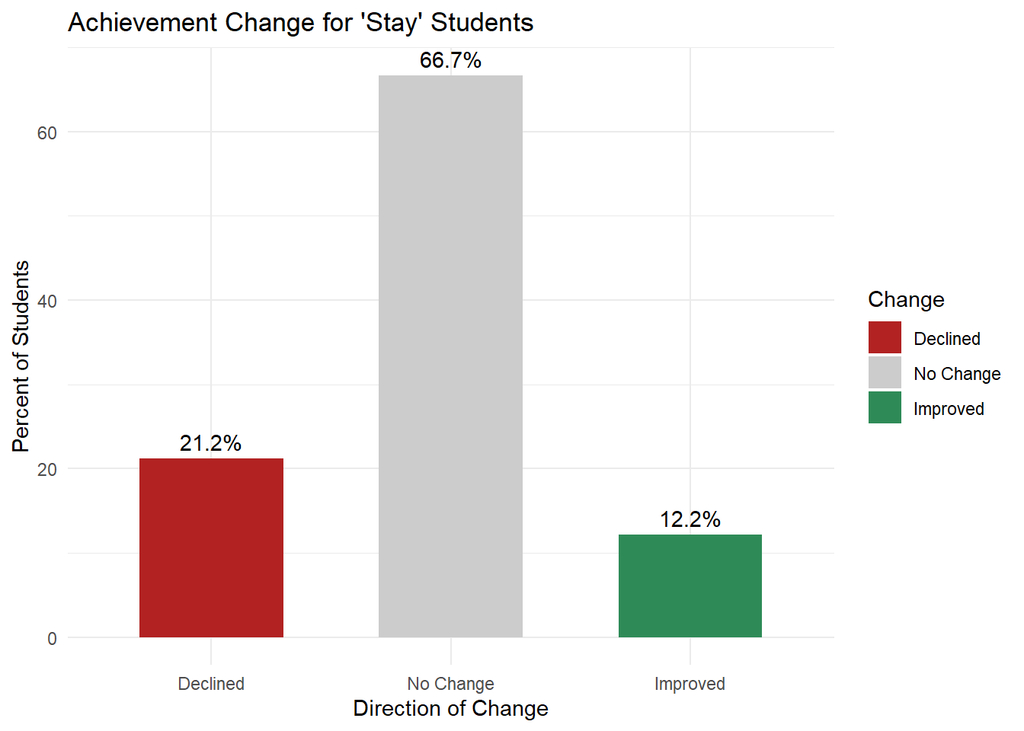

Among ‘Stay’ students (same cohort from both years), 12.2% improved, 66.7% had no change, 21.2% declined .

## 4.5 Most Common Achievement Levels

The most common performance level among ‘Stay’ students remained proficient in both 2022-2023 and 2023-2024 .

# 5 Achievement Trends

This section examines how student achievement in **Mathematics** has changed over time. By tracking the percentage of students who reached proficiency—based on state-defined achievement levels—we can identify long-term patterns in performance and assess progress across years.

In this analysis, we focus on **Grade 5**, examining achievement trends across multiple academic years.

Proficiency is defined as scoring at or above the following achievement level(s): **Proficient, Advanced**. In some cases, we also highlight students performing at advanced levels, which we define as scoring at or above **Advanced**. This distinction helps us monitor not only whether students are meeting expectations but also whether high-performing students are continuing to excel.

# 6 Appendices

## 6.1 Appendix: Cohort-Based Achievement Trends (Visual)

The chart below shows how proficiency rates have changed over time for each tested grade level. By aligning results from the same grade across multiple years, this visualization highlights patterns in student performance—such as overall improvement, decline, or stability at each grade.

This view helps contextualize performance across the system and may reveal whether certain grades consistently show higher or lower proficiency levels compared to others.

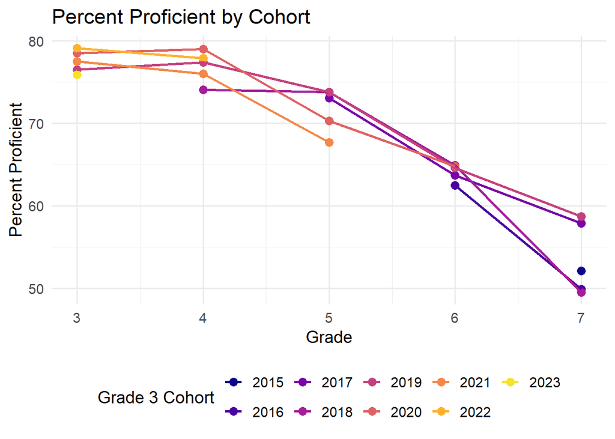

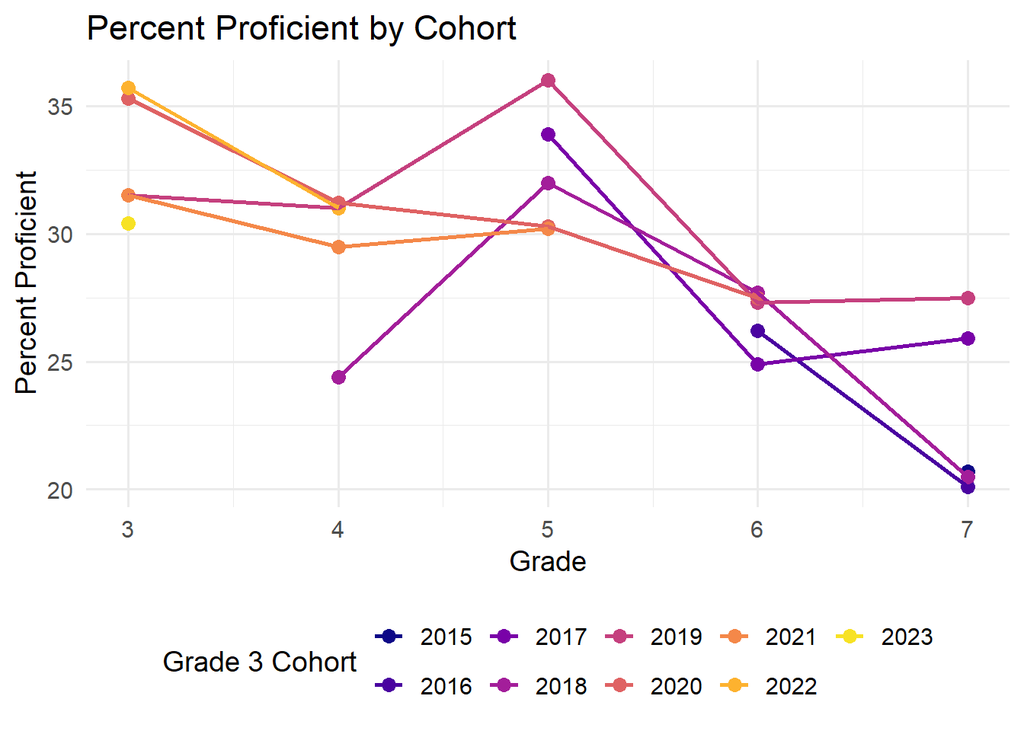

## 6.2 Appendix: Individual Cohort Heatmaps

### 6.2.1 Cohort Join Year: 2019

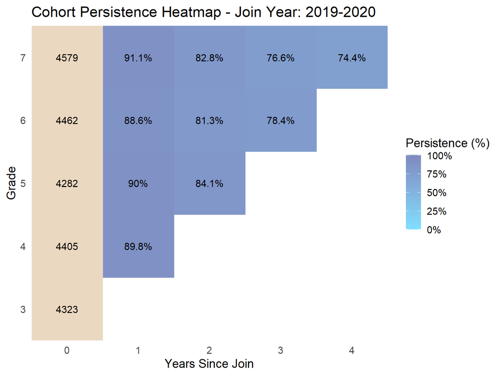

### 6.2.2 Cohort Join Year: 2020

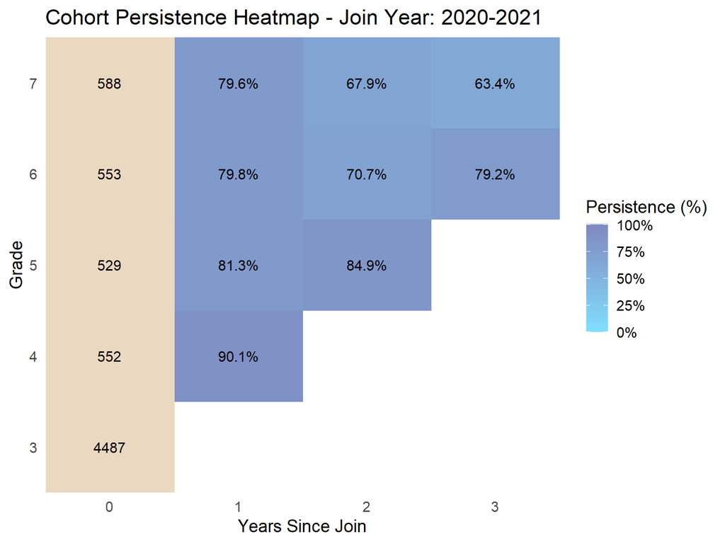

### 6.2.3 Cohort Join Year: 2021

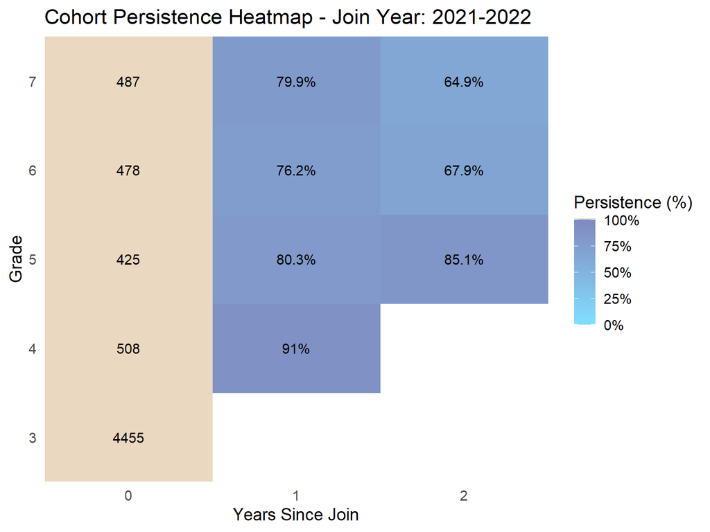

### 6.2.4 Cohort Join Year: 2022

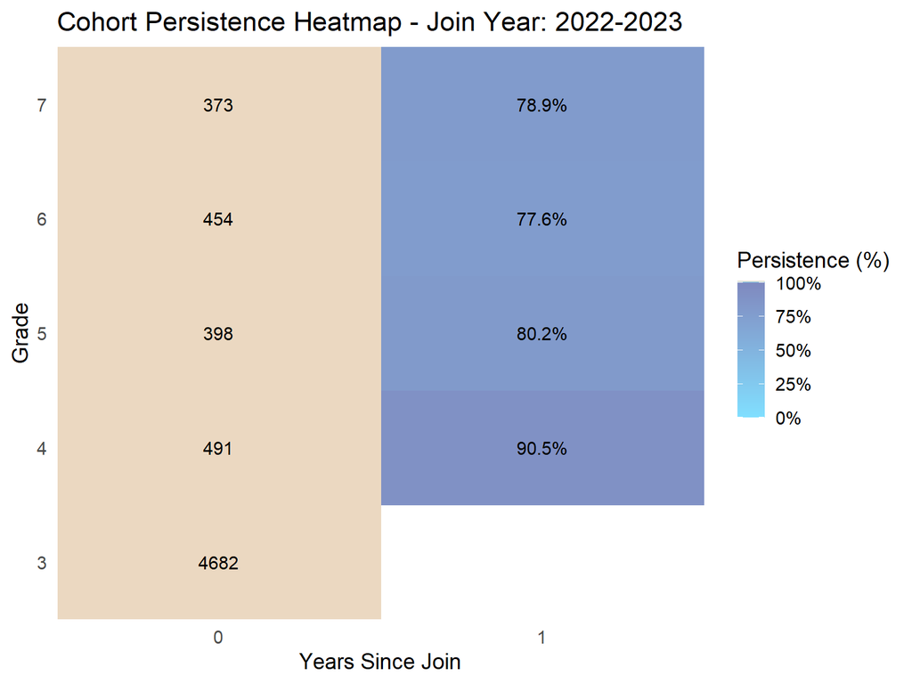

### 6.2.5 Cohort Join Year: 2023

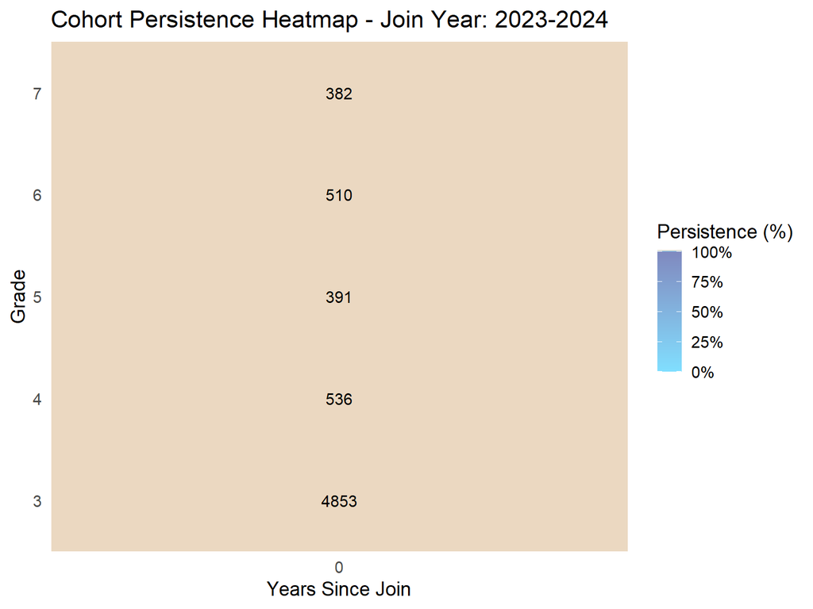